# Classification

Jeu de données res.PCA

.

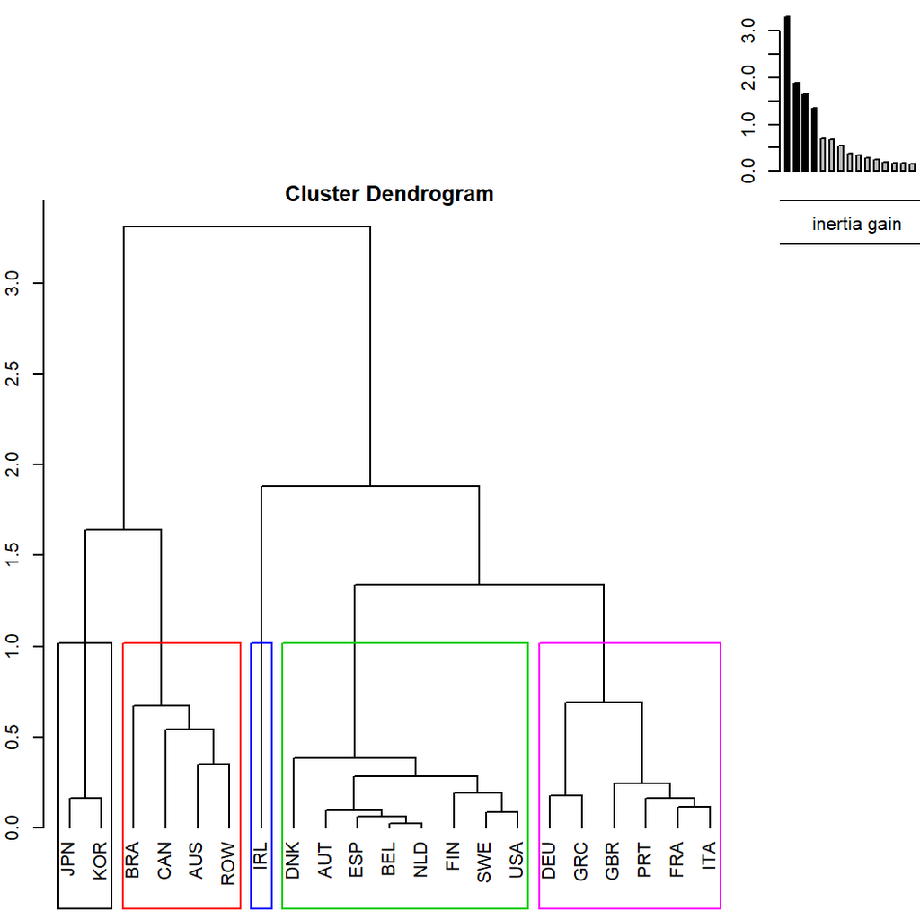

**Figure 1.1 - Arbre hiérarchique.**

La classification réalisée sur les individus fait apparaître 5 classes.

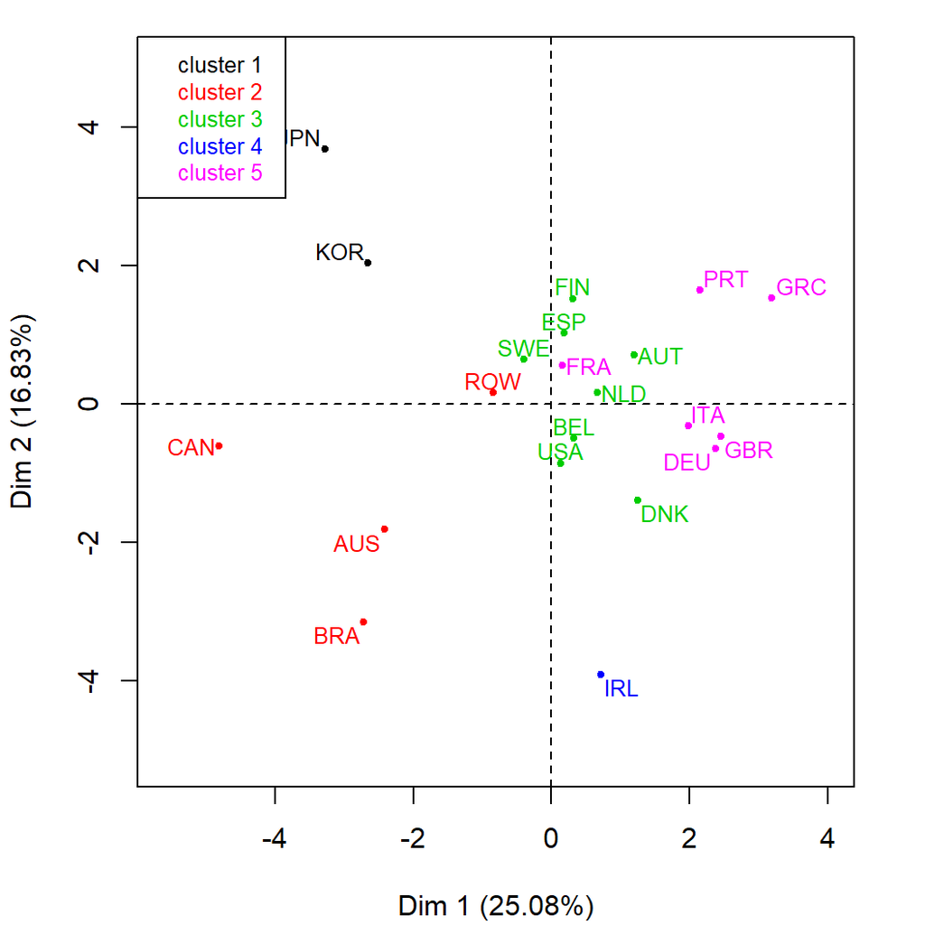

**Figure 1.2 - Classification Ascendante Hiérachique des individus.**

La **classe 1** est composée d’individus tels que *JPN* et *KOR*. Ce groupe est caractérisé par :

- de fortes valeurs pour les variables *OQ_Fwd*, *GZ_Fwd*, *IZ_Bwd*, *DE_Bwd*, *FZ_Bwd* et *RU_Bwd* (de la plus extrême à la moins extrême).
- de faibles valeurs pour les variables *FZ_Fwd* et *C1_Bwd* (de la plus extrême à la moins extrême).

La **classe 2** est composée d’individus tels que *AUS*, *BRA* et *CAN*. Ce groupe est caractérisé par :

- de fortes valeurs pour les variables *DE_Fwd*, *IZ_Fwd* et *RU_Fwd* (de la plus extrême à la moins extrême).
- de faibles valeurs pour les variables *C4_Fwd*, *HZ_Fwd*, *DE_Bwd* et *GZ_Bwd* (de la plus extrême à la moins extrême).

La **classe 3** est composé d’individus partageant :

- de fortes valeurs pour les variables *LZ_Bwd* et *AZ_Fwd* (de la plus extrême à la moins extrême).
- de faibles valeurs pour les variables *GZ_Fwd* et *C3_Bwd* (de la plus extrême à la moins extrême).

La **classe 4** est composée d’individus tels que *IRL*. Ce groupe est caractérisé par :

- de fortes valeurs pour les variables *JZ_Bwd*, *KZ_Fwd*, *GZ_Fwd*, *KZ_Bwd* et *MN_Fwd* (de la plus extrême à la moins extrême).
- de faibles valeurs pour les variables *C5_Fwd*, *C2_Fwd*, *IZ_Bwd*, *C1_Bwd* et *C4_Bwd* (de la plus extrême à la moins extrême).

La **classe 5** est composée d’individus tels que *DEU*, *GBR*, *GRC* et *PRT*. Ce groupe est caractérisé par :

- de fortes valeurs pour les variables *C3_Fwd*, *C2_Bwd* et *HZ_Fwd* (de la plus extrême à la moins extrême).
- de faibles valeurs pour les variables *AZ_Fwd*, *C1_Fwd* et *LZ_Bwd* (de la plus extrême à la moins extrême).

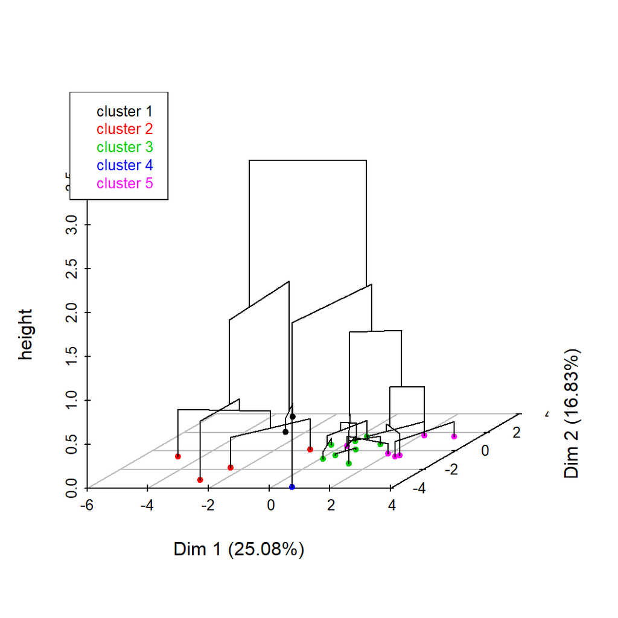

**Figure 1.3 - Arbre hiérarchique sur le plan factoriel.**

The hierarchical tree can be drawn on the factorial map with the individuals colored according to their clusters.